#Name: Sweta Kumari #Time series analysis #Read the global temperture file and check the columns name. #1. Read the global temperture file and check the columns name.

```r
GlobalTemperature<-read.csv("C:\\Users\\Sweta\\Documents\\Data\\GlobalTemperatures.csv",header=T)
attach(GlobalTemperature)
names(GlobalTemperature)
```

```
## [1] "dt"
## [2] "LandAverageTemperature"
## [3] "LandAverageTemperatureUncertainty"
## [4] "LandMaxTemperature"
## [5] "LandMaxTemperatureUncertainty"
## [6] "LandMinTemperature"
## [7] "LandMinTemperatureUncertainty"
## [8] "LandAndOceanAverageTemperature"
## [9] "LandAndOceanAverageTemperatureUncertainty"
```

#2. Importing librarries

```r
library(tidyverse)
```

```r
library(dplyr)
library(ggplot2)
library(lubridate)
library(fpp2)
library(zoo)
```

#3.#To review the changes in the ‘LandAverageTemperature’, we plot the graph of LandAverageTemperature vs time. #Analysis: From the graph, there is no outlier observed in the graph. #The Land Average Temperature is between 0 and 16 for the period of 1850 to 2015. #As the years passed, the average tempertaure of land has increased. #So, Average temperature is not stationary and showing upward trend.

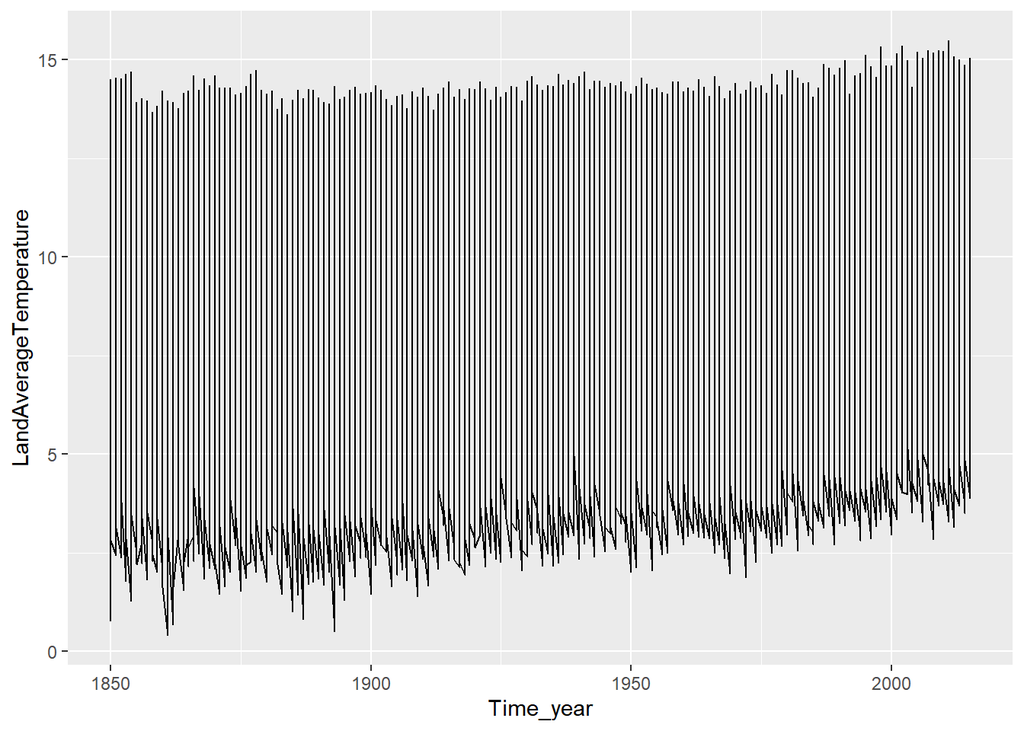

```r
Temperature <- GlobalTemperature %>% mutate(Time_year= year(dt)) %>% filter(Time_year>1849)
Temperature %>% group_by(Time_year) %>% ggplot(aes( x=Time_year,y=LandAverageTemperature,Colour=LandAverageTemperature)) + geom_line()
```

#4. To review the changes in the ‘LandAndOceanAverageTemperature’, we plot the graph of LandAndOceanAverageTemperature vs time. #Analysis: From the graph, there is no outlier observed in the graph. #The Land and Ocean Average Temperature is between 12 and 18 for the period of 1850 to 2015. #As the years passed, the average tempertaure has increased. #So, Average temperature is not stationary and showing upward trend. #We will check the seasonality with help of moving average method in last section

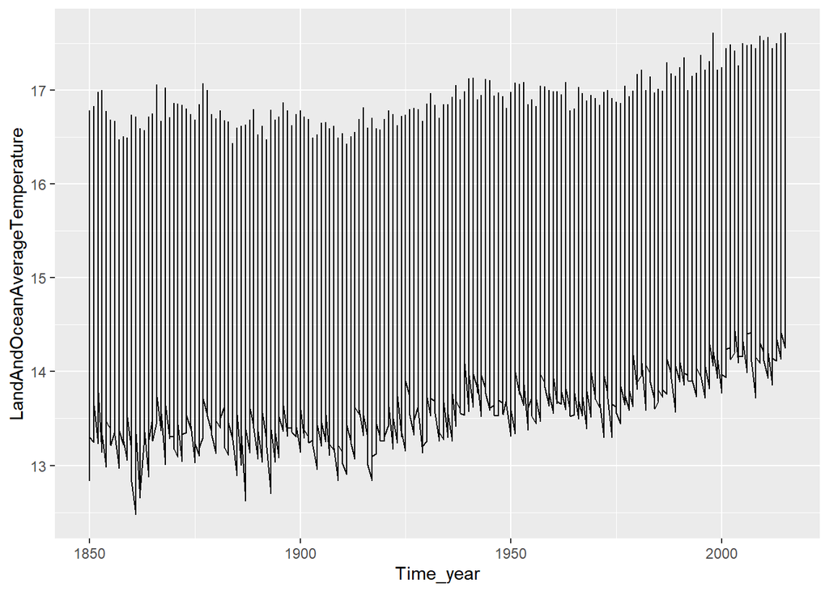

```r
Temperature %>% group_by(Time_year) %>% ggplot(aes( x=Time_year,y=LandAndOceanAverageTemperature,Colour=LandAndOceanAverageTemperature)) + geom_line()
```

#5. To review the changes in the ‘LandMaxTemperature’, we plot the graph of LandMaxTemperature vs time. #Analysis: From the graph, there is no outlier observed in the graph. #The Land Maximum Temperature is between 6 and 21 for the period of 1850 to 2015. #As the years passed, the maximum tempertaure of land has increased. #So, Land Max temperature is not stationary and showing upward trend.

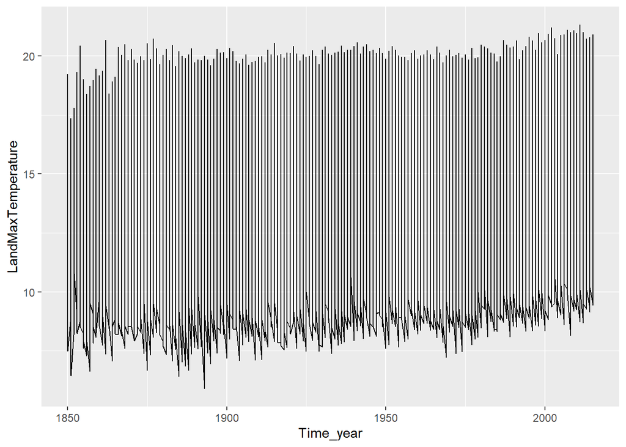

```r
Temperature %>% group_by(Time_year) %>% ggplot(aes( x=Time_year,y=LandMaxTemperature,Colour=LandMaxTemperature)) + geom_line()
```

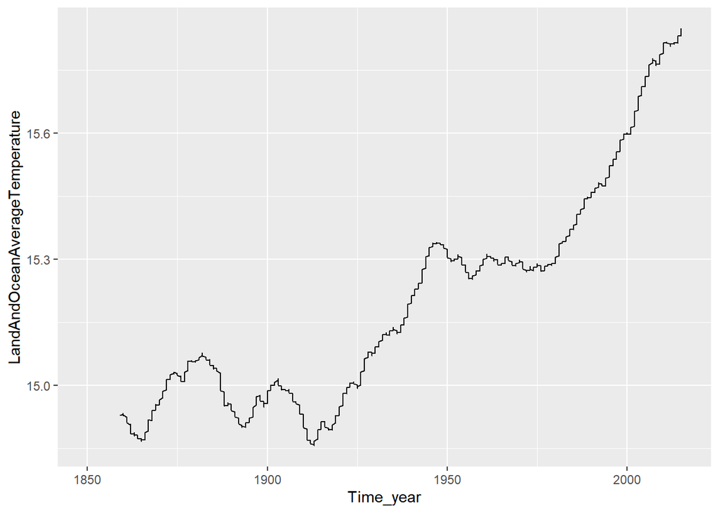

```r
LandTemperature <- GlobalTemperature  %>% mutate(LandAndOceanAverageTemperature = rollmean(LandAndOceanAverageTemperature, k = 120, fill = NA, align = "right"), Time_year=year(dt))
LandTemperature %>% group_by(Time_year) %>% filter(Time_year>1849) %>% ggplot(aes( x=Time_year,y=LandAndOceanAverageTemperature,Colour=LandAndOceanAverageTemperature)) + geom_line()
```